# COMPSCIX 415.2 Homework 3

Inessa Wu

February 13, 2018

```r
library(tidyverse)
library(nycflights13)
```

### Exercise 3.8.1

1. the graph likely does not plot all the points, can use position=jitter to see all data points

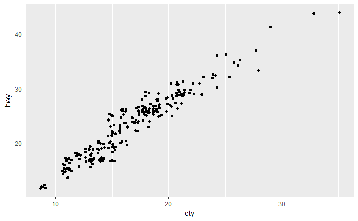

```r
ggplot(data = mpg, mapping = aes(x = cty, y = hwy)) +
  geom_point(position="jitter")
```

2. Amount and Factor control the degree of jittering in geom_jitter()

```r
?jitter
```

3. geom_jitter() can be used with scatterplots to alleviate overplotting by giving more separations to the points that are plotted in the same space. geom_count() is used to count number of points at each location and maps the count in various size of bubbles. geom_count might be more useful in large data sets since thescatterplot may already be too cluttered.
4. The default position adjustment for geom_boxplot() is position = “dodge”.

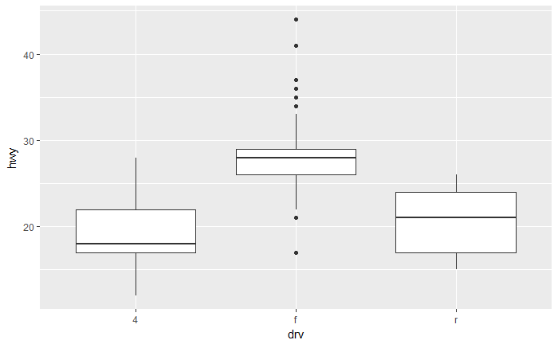

```r
ggplot(data=mpg)+
  geom_boxplot(mapping=aes(x=drv, y=hwy))
```

### Exercise 3.9.1

2. What does labs() modifies axis titles as well as plot titles and subtitles
3. The plot of highway vs city miles per gallon shows there is a direct relationships between city and hwy mileage performance - higher hwy mileage corresponds with higher city mileage. coord_fixed() forces a specified ratio between the physical representation of data units on the axes. It is important for clarity of data reporesentation so that the output is not misinterpreted. In this case x and y have the same units so fixed scale will give the best potrayal of the relationship between the two. geom_abline() Adds reference lines; helpful for plot evaluation

### Exercise 4.4

1.The code does not work because “my_varıable” is misspelled: ı instead of i 2. Correct dota to data

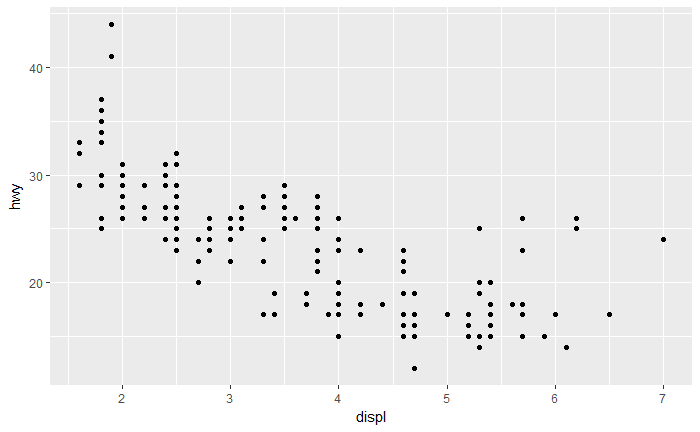

```r
library(tidyverse)
ggplot(data = mpg) +
  geom_point(mapping = aes(x = displ, y = hwy))
```

Correct “fliter” to “filter”

```r
filter(mpg, cyl == 8)
```

| manufacturer | model | displ | year | cyl | trans | drv | cty | hwy | fl | class |
| --- | --- | --- | --- | --- | --- | --- | --- | --- | --- | --- |
| audi | a6 quattro | 4.2 | 2008 | 8 | auto(s6) | 4 | 16 | 23 | p | midsize |
| chevrolet | c1500 suburban 2wd | 5.3 | 2008 | 8 | auto(l4) | r | 14 | 20 | r | suv |
| chevrolet | c1500 suburban 2wd | 5.3 | 2008 | 8 | auto(l4) | r | 11 | 15 | e | suv |
| chevrolet | c1500 suburban 2wd | 5.3 | 2008 | 8 | auto(l4) | r | 14 | 20 | r | suv |
| chevrolet | c1500 suburban 2wd | 5.7 | 1999 | 8 | auto(l4) | r | 13 | 17 | r | suv |
| chevrolet | c1500 suburban 2wd | 6.0 | 2008 | 8 | auto(l4) | r | 12 | 17 | r | suv |
| chevrolet | corvette | 5.7 | 1999 | 8 | manual(m6) | r | 16 | 26 | p | 2seater |
| chevrolet | corvette | 5.7 | 1999 | 8 | auto(l4) | r | 15 | 23 | p | 2seater |
| chevrolet | corvette | 6.2 | 2008 | 8 | manual(m6) | r | 16 | 26 | p | 2seater |
| chevrolet | corvette | 6.2 | 2008 | 8 | auto(s6) | r | 15 | 25 | p | 2seater |

[output cut: 60 more lines]

Correct “diamond” to “diamonds”

```r
filter(diamonds, carat > 3)
```

| carat | cut | color | clarity | depth | table | price | x | y | z |
| --- | --- | --- | --- | --- | --- | --- | --- | --- | --- |
| 3.01 | Premium | I | I1 | 62.7 | 58 | 8040 | 9.10 | 8.97 | 5.67 |
| 3.11 | Fair | J | I1 | 65.9 | 57 | 9823 | 9.15 | 9.02 | 5.98 |
| 3.01 | Premium | F | I1 | 62.2 | 56 | 9925 | 9.24 | 9.13 | 5.73 |
| 3.05 | Premium | E | I1 | 60.9 | 58 | 10453 | 9.26 | 9.25 | 5.66 |
| 3.02 | Fair | I | I1 | 65.2 | 56 | 10577 | 9.11 | 9.02 | 5.91 |
| 3.01 | Fair | H | I1 | 56.1 | 62 | 10761 | 9.54 | 9.38 | 5.31 |
| 3.65 | Fair | H | I1 | 67.1 | 53 | 11668 | 9.53 | 9.48 | 6.38 |
| 3.24 | Premium | H | I1 | 62.1 | 58 | 12300 | 9.44 | 9.40 | 5.85 |
| 3.22 | Ideal | I | I1 | 62.6 | 55 | 12545 | 9.49 | 9.42 | 5.92 |
| 3.50 | Ideal | H | I1 | 62.8 | 57 | 12587 | 9.65 | 9.59 | 6.03 |

[output cut: 22 more lines]

### Exercise 5.2.4

```r
library(tidyverse)
library(nycflights13)
```

```r
filter(flights, arr_delay>=2)
```

| year | month | day | dep_time | sched_dep_time | dep_delay | arr_time | sched_arr_time | arr_delay | carrier | flight | tailnum | origin | dest | air_time | distance | hour | minute | time_hour |
| --- | --- | --- | --- | --- | --- | --- | --- | --- | --- | --- | --- | --- | --- | --- | --- | --- | --- | --- |
| 2013 | 1 | 1 | 517 | 515 | 2 | 830 | 819 | 11 | UA | 1545 | N14228 | EWR | IAH | 227 | 1400 | 5 | 15 | 2013-01-01 05:00:00 |
| 2013 | 1 | 1 | 533 | 529 | 4 | 850 | 830 | 20 | UA | 1714 | N24211 | LGA | IAH | 227 | 1416 | 5 | 29 | 2013-01-01 05:00:00 |
| 2013 | 1 | 1 | 542 | 540 | 2 | 923 | 850 | 33 | AA | 1141 | N619AA | JFK | MIA | 160 | 1089 | 5 | 40 | 2013-01-01 05:00:00 |
| 2013 | 1 | 1 | 554 | 558 | -4 | 740 | 728 | 12 | UA | 1696 | N39463 | EWR | ORD | 150 | 719 | 5 | 58 | 2013-01-01 05:00:00 |
| 2013 | 1 | 1 | 555 | 600 | -5 | 913 | 854 | 19 | B6 | 507 | N516JB | EWR | FLL | 158 | 1065 | 6 | 0 | 2013-01-01 06:00:00 |
| 2013 | 1 | 1 | 558 | 600 | -2 | 753 | 745 | 8 | AA | 301 | N3ALAA | LGA | ORD | 138 | 733 | 6 | 0 | 2013-01-01 06:00:00 |
| 2013 | 1 | 1 | 558 | 600 | -2 | 924 | 917 | 7 | UA | 194 | N29129 | JFK | LAX | 345 | 2475 | 6 | 0 | 2013-01-01 06:00:00 |
| 2013 | 1 | 1 | 559 | 600 | -1 | 941 | 910 | 31 | AA | 707 | N3DUAA | LGA | DFW | 257 | 1389 | 6 | 0 | 2013-01-01 06:00:00 |
| 2013 | 1 | 1 | 600 | 600 | 0 | 837 | 825 | 12 | MQ | 4650 | N542MQ | LGA | ATL | 134 | 762 | 6 | 0 | 2013-01-01 06:00:00 |
| 2013 | 1 | 1 | 602 | 605 | -3 | 821 | 805 | 16 | MQ | 4401 | N730MQ | LGA | DTW | 105 | 502 | 6 | 5 | 2013-01-01 06:00:00 |

[output cut: 990 more lines]

Flew to Houston (IAH or HOU)

```r
filter(flights, dest=="IAH" | dest=="HOU")
```

| year | month | day | dep_time | sched_dep_time | dep_delay | arr_time | sched_arr_time | arr_delay | carrier | flight | tailnum | origin | dest | air_time | distance | hour | minute | time_hour |
| --- | --- | --- | --- | --- | --- | --- | --- | --- | --- | --- | --- | --- | --- | --- | --- | --- | --- | --- |
| 2013 | 1 | 1 | 517 | 515 | 2 | 830 | 819 | 11 | UA | 1545 | N14228 | EWR | IAH | 227 | 1400 | 5 | 15 | 2013-01-01 05:00:00 |
| 2013 | 1 | 1 | 533 | 529 | 4 | 850 | 830 | 20 | UA | 1714 | N24211 | LGA | IAH | 227 | 1416 | 5 | 29 | 2013-01-01 05:00:00 |
| 2013 | 1 | 1 | 623 | 627 | -4 | 933 | 932 | 1 | UA | 496 | N459UA | LGA | IAH | 229 | 1416 | 6 | 27 | 2013-01-01 06:00:00 |
| 2013 | 1 | 1 | 728 | 732 | -4 | 1041 | 1038 | 3 | UA | 473 | N488UA | LGA | IAH | 238 | 1416 | 7 | 32 | 2013-01-01 07:00:00 |
| 2013 | 1 | 1 | 739 | 739 | 0 | 1104 | 1038 | 26 | UA | 1479 | N37408 | EWR | IAH | 249 | 1400 | 7 | 39 | 2013-01-01 07:00:00 |
| 2013 | 1 | 1 | 908 | 908 | 0 | 1228 | 1219 | 9 | UA | 1220 | N12216 | EWR | IAH | 233 | 1400 | 9 | 8 | 2013-01-01 09:00:00 |
| 2013 | 1 | 1 | 1028 | 1026 | 2 | 1350 | 1339 | 11 | UA | 1004 | N76508 | LGA | IAH | 237 | 1416 | 10 | 26 | 2013-01-01 10:00:00 |
| 2013 | 1 | 1 | 1044 | 1045 | -1 | 1352 | 1351 | 1 | UA | 455 | N667UA | EWR | IAH | 229 | 1400 | 10 | 45 | 2013-01-01 10:00:00 |
| 2013 | 1 | 1 | 1114 | 900 | 134 | 1447 | 1222 | 145 | UA | 1086 | N76502 | LGA | IAH | 248 | 1416 | 9 | 0 | 2013-01-01 09:00:00 |
| 2013 | 1 | 1 | 1205 | 1200 | 5 | 1503 | 1505 | -2 | UA | 1461 | N39418 | EWR | IAH | 221 | 1400 | 12 | 0 | 2013-01-01 12:00:00 |

[output cut: 990 more lines]

Were operated by United, American, or Delta

```r
filter(flights, carrier %in% c("UA", "AA", "DL"))
```

| year | month | day | dep_time | sched_dep_time | dep_delay | arr_time | sched_arr_time | arr_delay | carrier | flight | tailnum | origin | dest | air_time | distance | hour | minute | time_hour |
| --- | --- | --- | --- | --- | --- | --- | --- | --- | --- | --- | --- | --- | --- | --- | --- | --- | --- | --- |
| 2013 | 1 | 1 | 517 | 515 | 2 | 830 | 819 | 11 | UA | 1545 | N14228 | EWR | IAH | 227 | 1400 | 5 | 15 | 2013-01-01 05:00:00 |
| 2013 | 1 | 1 | 533 | 529 | 4 | 850 | 830 | 20 | UA | 1714 | N24211 | LGA | IAH | 227 | 1416 | 5 | 29 | 2013-01-01 05:00:00 |
| 2013 | 1 | 1 | 542 | 540 | 2 | 923 | 850 | 33 | AA | 1141 | N619AA | JFK | MIA | 160 | 1089 | 5 | 40 | 2013-01-01 05:00:00 |
| 2013 | 1 | 1 | 554 | 600 | -6 | 812 | 837 | -25 | DL | 461 | N668DN | LGA | ATL | 116 | 762 | 6 | 0 | 2013-01-01 06:00:00 |
| 2013 | 1 | 1 | 554 | 558 | -4 | 740 | 728 | 12 | UA | 1696 | N39463 | EWR | ORD | 150 | 719 | 5 | 58 | 2013-01-01 05:00:00 |
| 2013 | 1 | 1 | 558 | 600 | -2 | 753 | 745 | 8 | AA | 301 | N3ALAA | LGA | ORD | 138 | 733 | 6 | 0 | 2013-01-01 06:00:00 |
| 2013 | 1 | 1 | 558 | 600 | -2 | 924 | 917 | 7 | UA | 194 | N29129 | JFK | LAX | 345 | 2475 | 6 | 0 | 2013-01-01 06:00:00 |
| 2013 | 1 | 1 | 558 | 600 | -2 | 923 | 937 | -14 | UA | 1124 | N53441 | EWR | SFO | 361 | 2565 | 6 | 0 | 2013-01-01 06:00:00 |
| 2013 | 1 | 1 | 559 | 600 | -1 | 941 | 910 | 31 | AA | 707 | N3DUAA | LGA | DFW | 257 | 1389 | 6 | 0 | 2013-01-01 06:00:00 |
| 2013 | 1 | 1 | 559 | 600 | -1 | 854 | 902 | -8 | UA | 1187 | N76515 | EWR | LAS | 337 | 2227 | 6 | 0 | 2013-01-01 06:00:00 |

[output cut: 990 more lines]

Departed in summer (July, August, and September)

```r
filter(flights, month %in% c(7, 8, 9))
```

| year | month | day | dep_time | sched_dep_time | dep_delay | arr_time | sched_arr_time | arr_delay | carrier | flight | tailnum | origin | dest | air_time | distance | hour | minute | time_hour |
| --- | --- | --- | --- | --- | --- | --- | --- | --- | --- | --- | --- | --- | --- | --- | --- | --- | --- | --- |
| 2013 | 7 | 1 | 1 | 2029 | 212 | 236 | 2359 | 157 | B6 | 915 | N653JB | JFK | SFO | 315 | 2586 | 20 | 29 | 2013-07-01 20:00:00 |
| 2013 | 7 | 1 | 2 | 2359 | 3 | 344 | 344 | 0 | B6 | 1503 | N805JB | JFK | SJU | 200 | 1598 | 23 | 59 | 2013-07-01 23:00:00 |
| 2013 | 7 | 1 | 29 | 2245 | 104 | 151 | 1 | 110 | B6 | 234 | N348JB | JFK | BTV | 66 | 266 | 22 | 45 | 2013-07-01 22:00:00 |
| 2013 | 7 | 1 | 43 | 2130 | 193 | 322 | 14 | 188 | B6 | 1371 | N794JB | LGA | FLL | 143 | 1076 | 21 | 30 | 2013-07-01 21:00:00 |
| 2013 | 7 | 1 | 44 | 2150 | 174 | 300 | 100 | 120 | AA | 185 | N324AA | JFK | LAX | 297 | 2475 | 21 | 50 | 2013-07-01 21:00:00 |
| 2013 | 7 | 1 | 46 | 2051 | 235 | 304 | 2358 | 186 | B6 | 165 | N640JB | JFK | PDX | 304 | 2454 | 20 | 51 | 2013-07-01 20:00:00 |
| 2013 | 7 | 1 | 48 | 2001 | 287 | 308 | 2305 | 243 | VX | 415 | N627VA | JFK | LAX | 298 | 2475 | 20 | 1 | 2013-07-01 20:00:00 |
| 2013 | 7 | 1 | 58 | 2155 | 183 | 335 | 43 | 172 | B6 | 425 | N535JB | JFK | TPA | 140 | 1005 | 21 | 55 | 2013-07-01 21:00:00 |
| 2013 | 7 | 1 | 100 | 2146 | 194 | 327 | 30 | 177 | B6 | 1183 | N531JB | JFK | MCO | 126 | 944 | 21 | 46 | 2013-07-01 21:00:00 |
| 2013 | 7 | 1 | 100 | 2245 | 135 | 337 | 135 | 122 | B6 | 623 | N663JB | JFK | LAX | 304 | 2475 | 22 | 45 | 2013-07-01 22:00:00 |

[output cut: 990 more lines]

Arrived more than two hours late, but didn’t leave late

```r
filter(flights, dep_delay<=0, arr_delay>120)
```

| year | month | day | dep_time | sched_dep_time | dep_delay | arr_time | sched_arr_time | arr_delay | carrier | flight | tailnum | origin | dest | air_time | distance | hour | minute | time_hour |
| --- | --- | --- | --- | --- | --- | --- | --- | --- | --- | --- | --- | --- | --- | --- | --- | --- | --- | --- |
| 2013 | 1 | 27 | 1419 | 1420 | -1 | 1754 | 1550 | 124 | MQ | 3728 | N1EAMQ | EWR | ORD | 135 | 719 | 14 | 20 | 2013-01-27 14:00:00 |
| 2013 | 10 | 7 | 1350 | 1350 | 0 | 1736 | 1526 | 130 | EV | 5181 | N611QX | LGA | MSN | 117 | 812 | 13 | 50 | 2013-10-07 13:00:00 |
| 2013 | 10 | 7 | 1357 | 1359 | -2 | 1858 | 1654 | 124 | AA | 1151 | N3CMAA | LGA | DFW | 192 | 1389 | 13 | 59 | 2013-10-07 13:00:00 |
| 2013 | 10 | 16 | 657 | 700 | -3 | 1258 | 1056 | 122 | B6 | 3 | N703JB | JFK | SJU | 225 | 1598 | 7 | 0 | 2013-10-16 07:00:00 |
| 2013 | 11 | 1 | 658 | 700 | -2 | 1329 | 1015 | 194 | VX | 399 | N629VA | JFK | LAX | 336 | 2475 | 7 | 0 | 2013-11-01 07:00:00 |
| 2013 | 3 | 18 | 1844 | 1847 | -3 | 39 | 2219 | 140 | UA | 389 | N560UA | JFK | SFO | 386 | 2586 | 18 | 47 | 2013-03-18 18:00:00 |
| 2013 | 4 | 17 | 1635 | 1640 | -5 | 2049 | 1845 | 124 | MQ | 4540 | N721MQ | LGA | DTW | 130 | 502 | 16 | 40 | 2013-04-17 16:00:00 |
| 2013 | 4 | 18 | 558 | 600 | -2 | 1149 | 850 | 179 | AA | 707 | N3EXAA | LGA | DFW | 234 | 1389 | 6 | 0 | 2013-04-18 06:00:00 |
| 2013 | 4 | 18 | 655 | 700 | -5 | 1213 | 950 | 143 | AA | 2083 | N565AA | EWR | DFW | 230 | 1372 | 7 | 0 | 2013-04-18 07:00:00 |
| 2013 | 5 | 22 | 1827 | 1830 | -3 | 2217 | 2010 | 127 | MQ | 4674 | N518MQ | LGA | CLE | 90 | 419 | 18 | 30 | 2013-05-22 18:00:00 |

[output cut: 19 more lines]

Were delayed by at least an hour, but made up over 30 minutes in flight

```r
filter(flights, dep_delay>=60, (dep_delay-arr_delay)>30)
```

| year | month | day | dep_time | sched_dep_time | dep_delay | arr_time | sched_arr_time | arr_delay | carrier | flight | tailnum | origin | dest | air_time | distance | hour | minute | time_hour |
| --- | --- | --- | --- | --- | --- | --- | --- | --- | --- | --- | --- | --- | --- | --- | --- | --- | --- | --- |
| 2013 | 1 | 1 | 2205 | 1720 | 285 | 46 | 2040 | 246 | AA | 1999 | N5DNAA | EWR | MIA | 146 | 1085 | 17 | 20 | 2013-01-01 17:00:00 |
| 2013 | 1 | 1 | 2326 | 2130 | 116 | 131 | 18 | 73 | B6 | 199 | N594JB | JFK | LAS | 290 | 2248 | 21 | 30 | 2013-01-01 21:00:00 |
| 2013 | 1 | 3 | 1503 | 1221 | 162 | 1803 | 1555 | 128 | UA | 551 | N835UA | EWR | SFO | 320 | 2565 | 12 | 21 | 2013-01-03 12:00:00 |
| 2013 | 1 | 3 | 1839 | 1700 | 99 | 2056 | 1950 | 66 | AA | 575 | N631AA | JFK | EGE | 239 | 1747 | 17 | 0 | 2013-01-03 17:00:00 |
| 2013 | 1 | 3 | 1850 | 1745 | 65 | 2148 | 2120 | 28 | AA | 177 | N332AA | JFK | SFO | 314 | 2586 | 17 | 45 | 2013-01-03 17:00:00 |
| 2013 | 1 | 3 | 1941 | 1759 | 102 | 2246 | 2139 | 67 | UA | 979 | N402UA | EWR | PHX | 274 | 2133 | 17 | 59 | 2013-01-03 17:00:00 |
| 2013 | 1 | 3 | 1950 | 1845 | 65 | 2228 | 2227 | 1 | B6 | 91 | N636JB | JFK | OAK | 319 | 2576 | 18 | 45 | 2013-01-03 18:00:00 |
| 2013 | 1 | 3 | 2015 | 1915 | 60 | 2135 | 2111 | 24 | 9E | 3525 | N903XJ | JFK | ORD | 110 | 740 | 19 | 15 | 2013-01-03 19:00:00 |
| 2013 | 1 | 3 | 2257 | 2000 | 177 | 45 | 2224 | 141 | 9E | 3439 | N931XJ | JFK | CVG | 90 | 589 | 20 | 0 | 2013-01-03 20:00:00 |
| 2013 | 1 | 4 | 1917 | 1700 | 137 | 2135 | 1950 | 105 | AA | 575 | N5EUAA | JFK | EGE | 239 | 1747 | 17 | 0 | 2013-01-04 17:00:00 |

[output cut: 990 more lines]

Departed between midnight and 6am (inclusive)

```r
filter(flights, sched_dep_time>=0000, sched_dep_time<=0600)
```

| year | month | day | dep_time | sched_dep_time | dep_delay | arr_time | sched_arr_time | arr_delay | carrier | flight | tailnum | origin | dest | air_time | distance | hour | minute | time_hour |
| --- | --- | --- | --- | --- | --- | --- | --- | --- | --- | --- | --- | --- | --- | --- | --- | --- | --- | --- |
| 2013 | 1 | 1 | 517 | 515 | 2 | 830 | 819 | 11 | UA | 1545 | N14228 | EWR | IAH | 227 | 1400 | 5 | 15 | 2013-01-01 05:00:00 |
| 2013 | 1 | 1 | 533 | 529 | 4 | 850 | 830 | 20 | UA | 1714 | N24211 | LGA | IAH | 227 | 1416 | 5 | 29 | 2013-01-01 05:00:00 |
| 2013 | 1 | 1 | 542 | 540 | 2 | 923 | 850 | 33 | AA | 1141 | N619AA | JFK | MIA | 160 | 1089 | 5 | 40 | 2013-01-01 05:00:00 |
| 2013 | 1 | 1 | 544 | 545 | -1 | 1004 | 1022 | -18 | B6 | 725 | N804JB | JFK | BQN | 183 | 1576 | 5 | 45 | 2013-01-01 05:00:00 |
| 2013 | 1 | 1 | 554 | 600 | -6 | 812 | 837 | -25 | DL | 461 | N668DN | LGA | ATL | 116 | 762 | 6 | 0 | 2013-01-01 06:00:00 |
| 2013 | 1 | 1 | 554 | 558 | -4 | 740 | 728 | 12 | UA | 1696 | N39463 | EWR | ORD | 150 | 719 | 5 | 58 | 2013-01-01 05:00:00 |
| 2013 | 1 | 1 | 555 | 600 | -5 | 913 | 854 | 19 | B6 | 507 | N516JB | EWR | FLL | 158 | 1065 | 6 | 0 | 2013-01-01 06:00:00 |
| 2013 | 1 | 1 | 557 | 600 | -3 | 709 | 723 | -14 | EV | 5708 | N829AS | LGA | IAD | 53 | 229 | 6 | 0 | 2013-01-01 06:00:00 |
| 2013 | 1 | 1 | 557 | 600 | -3 | 838 | 846 | -8 | B6 | 79 | N593JB | JFK | MCO | 140 | 944 | 6 | 0 | 2013-01-01 06:00:00 |
| 2013 | 1 | 1 | 558 | 600 | -2 | 753 | 745 | 8 | AA | 301 | N3ALAA | LGA | ORD | 138 | 733 | 6 | 0 | 2013-01-01 06:00:00 |

[output cut: 990 more lines]

2. between() filters values within the specified range

Departed between midnight and 6am (inclusive)

```r
filter(flights, between(sched_dep_time, 0000, 0600))
```

| year | month | day | dep_time | sched_dep_time | dep_delay | arr_time | sched_arr_time | arr_delay | carrier | flight | tailnum | origin | dest | air_time | distance | hour | minute | time_hour |
| --- | --- | --- | --- | --- | --- | --- | --- | --- | --- | --- | --- | --- | --- | --- | --- | --- | --- | --- |
| 2013 | 1 | 1 | 517 | 515 | 2 | 830 | 819 | 11 | UA | 1545 | N14228 | EWR | IAH | 227 | 1400 | 5 | 15 | 2013-01-01 05:00:00 |
| 2013 | 1 | 1 | 533 | 529 | 4 | 850 | 830 | 20 | UA | 1714 | N24211 | LGA | IAH | 227 | 1416 | 5 | 29 | 2013-01-01 05:00:00 |
| 2013 | 1 | 1 | 542 | 540 | 2 | 923 | 850 | 33 | AA | 1141 | N619AA | JFK | MIA | 160 | 1089 | 5 | 40 | 2013-01-01 05:00:00 |
| 2013 | 1 | 1 | 544 | 545 | -1 | 1004 | 1022 | -18 | B6 | 725 | N804JB | JFK | BQN | 183 | 1576 | 5 | 45 | 2013-01-01 05:00:00 |
| 2013 | 1 | 1 | 554 | 600 | -6 | 812 | 837 | -25 | DL | 461 | N668DN | LGA | ATL | 116 | 762 | 6 | 0 | 2013-01-01 06:00:00 |
| 2013 | 1 | 1 | 554 | 558 | -4 | 740 | 728 | 12 | UA | 1696 | N39463 | EWR | ORD | 150 | 719 | 5 | 58 | 2013-01-01 05:00:00 |
| 2013 | 1 | 1 | 555 | 600 | -5 | 913 | 854 | 19 | B6 | 507 | N516JB | EWR | FLL | 158 | 1065 | 6 | 0 | 2013-01-01 06:00:00 |
| 2013 | 1 | 1 | 557 | 600 | -3 | 709 | 723 | -14 | EV | 5708 | N829AS | LGA | IAD | 53 | 229 | 6 | 0 | 2013-01-01 06:00:00 |
| 2013 | 1 | 1 | 557 | 600 | -3 | 838 | 846 | -8 | B6 | 79 | N593JB | JFK | MCO | 140 | 944 | 6 | 0 | 2013-01-01 06:00:00 |
| 2013 | 1 | 1 | 558 | 600 | -2 | 753 | 745 | 8 | AA | 301 | N3ALAA | LGA | ORD | 138 | 733 | 6 | 0 | 2013-01-01 06:00:00 |

[output cut: 990 more lines]

3. 8,255 flights have a missing dep_time. Dep_delay, arr_time, arr_delay are slaso missing. These might be cancelled flights.

```r
(missing_dep_time <- filter(flights, is.na(dep_time)))
```

| year | month | day | dep_time | sched_dep_time | dep_delay | arr_time | sched_arr_time | arr_delay | carrier | flight | tailnum | origin | dest | air_time | distance | hour | minute | time_hour |
| --- | --- | --- | --- | --- | --- | --- | --- | --- | --- | --- | --- | --- | --- | --- | --- | --- | --- | --- |
| 2013 | 1 | 1 | NA | 1630 | NA | NA | 1815 | NA | EV | 4308 | N18120 | EWR | RDU | NA | 416 | 16 | 30 | 2013-01-01 16:00:00 |
| 2013 | 1 | 1 | NA | 1935 | NA | NA | 2240 | NA | AA | 791 | N3EHAA | LGA | DFW | NA | 1389 | 19 | 35 | 2013-01-01 19:00:00 |
| 2013 | 1 | 1 | NA | 1500 | NA | NA | 1825 | NA | AA | 1925 | N3EVAA | LGA | MIA | NA | 1096 | 15 | 0 | 2013-01-01 15:00:00 |
| 2013 | 1 | 1 | NA | 600 | NA | NA | 901 | NA | B6 | 125 | N618JB | JFK | FLL | NA | 1069 | 6 | 0 | 2013-01-01 06:00:00 |
| 2013 | 1 | 2 | NA | 1540 | NA | NA | 1747 | NA | EV | 4352 | N10575 | EWR | CVG | NA | 569 | 15 | 40 | 2013-01-02 15:00:00 |
| 2013 | 1 | 2 | NA | 1620 | NA | NA | 1746 | NA | EV | 4406 | N13949 | EWR | PIT | NA | 319 | 16 | 20 | 2013-01-02 16:00:00 |
| 2013 | 1 | 2 | NA | 1355 | NA | NA | 1459 | NA | EV | 4434 | N10575 | EWR | MHT | NA | 209 | 13 | 55 | 2013-01-02 13:00:00 |
| 2013 | 1 | 2 | NA | 1420 | NA | NA | 1644 | NA | EV | 4935 | N759EV | EWR | ATL | NA | 746 | 14 | 20 | 2013-01-02 14:00:00 |
| 2013 | 1 | 2 | NA | 1321 | NA | NA | 1536 | NA | EV | 3849 | N13550 | EWR | IND | NA | 645 | 13 | 21 | 2013-01-02 13:00:00 |
| 2013 | 1 | 2 | NA | 1545 | NA | NA | 1910 | NA | AA | 133 | NA | JFK | LAX | NA | 2475 | 15 | 45 | 2013-01-02 15:00:00 |

[output cut: 990 more lines]

```r
count(missing_dep_time)
```

| n |
| --- |
| 8255 |

4. Why is NA ^ 0 not missing? Any value to power if zero is equal to 1, including any unknown value Why is NA | TRUE not missing? This is an OR statement which returns TRUE if either of the terms is TRUE, which is correct in this situation Why is FALSE & NA not missing? & operator will return TRUE only if both terms are the same. In this case we do not know what NA terms are which is why FALSE is returned Can you figure out the general rule? (NA * 0 is a tricky counterexample!). If the operation does not care whether NA is an integer or not, the response will be not missing, It will be missing if the operation can be perfomed on specific variable type only

```r
NA^0
```

```
[1] 1
```

```r
NA|TRUE
```

```
[1] TRUE
```

```r
FALSE & NA
```

```
[1] FALSE
```

### Exercise 5.4.1

1. Brainstorm as many ways as possible to select dep_time, dep_delay, arr_time, and arr_delay from flights

```r
select(flights, dep_time, dep_delay, arr_time, arr_delay)
```

| dep_time | dep_delay | arr_time | arr_delay |
| --- | --- | --- | --- |
| 517 | 2 | 830 | 11 |
| 533 | 4 | 850 | 20 |
| 542 | 2 | 923 | 33 |
| 544 | -1 | 1004 | -18 |
| 554 | -6 | 812 | -25 |
| 554 | -4 | 740 | 12 |
| 555 | -5 | 913 | 19 |
| 557 | -3 | 709 | -14 |
| 557 | -3 | 838 | -8 |
| 558 | -2 | 753 | 8 |

[output cut: 990 more lines]

```r
select(flights, dep_time:arr_delay, -(sched_dep_time), -(sched_arr_time))
```

| dep_time | dep_delay | arr_time | arr_delay |
| --- | --- | --- | --- |
| 517 | 2 | 830 | 11 |
| 533 | 4 | 850 | 20 |
| 542 | 2 | 923 | 33 |
| 544 | -1 | 1004 | -18 |
| 554 | -6 | 812 | -25 |
| 554 | -4 | 740 | 12 |
| 555 | -5 | 913 | 19 |
| 557 | -3 | 709 | -14 |
| 557 | -3 | 838 | -8 |
| 558 | -2 | 753 | 8 |

[output cut: 990 more lines]

2. What happens if you include the name of a variable multiple times in a select() call. Nothing, variable listed multiple times shows up only once

```r
select(flights, dep_time, dep_time)
```

| dep_time |
| --- |
| 517 |
| 533 |
| 542 |
| 544 |
| 554 |
| 554 |
| 555 |
| 557 |
| 557 |
| 558 |

[output cut: 990 more lines]

3. one_of() function aloows you to call a predetermined set of columns instead of explicitly listing out column headers in select() function? Might it be helpful in conjunction with this vector if the same set of columns will be needed multiple times throughout the code.

```r
(vars <- c("year", "month", "day", "dep_delay", "arr_delay"))
```

```
[1] "year"      "month"     "day"       "dep_delay" "arr_delay"
```

```r
select(flights, one_of(vars))
```

| year | month | day | dep_delay | arr_delay |
| --- | --- | --- | --- | --- |
| 2013 | 1 | 1 | 2 | 11 |
| 2013 | 1 | 1 | 4 | 20 |
| 2013 | 1 | 1 | 2 | 33 |
| 2013 | 1 | 1 | -1 | -18 |
| 2013 | 1 | 1 | -6 | -25 |
| 2013 | 1 | 1 | -4 | 12 |
| 2013 | 1 | 1 | -5 | 19 |
| 2013 | 1 | 1 | -3 | -14 |
| 2013 | 1 | 1 | -3 | -8 |
| 2013 | 1 | 1 | -2 | 8 |

[output cut: 990 more lines]

4. Argument in contians () function is case insesitive. this is surpirising given that R is case sensitive in general. Default is case insensitive. To change to case sensitive include ignore.case=FALSE

```r
select(flights, contains("TIME", ignore.case = FALSE))
```